# NEPA Decarbonization Technology Analysis: Deliverable 5

Categorical Exclusion Spikes After Major Infrastructure Legislation

Published

August 21, 2026

# Executive Summary

This deliverable examines whether the use of categorical exclusions (CEs), the lightest form of NEPA review, spikes after the passage of major infrastructure legislation, and if so, whether those actions are demonstrably tied to the new law. We anchor every CE to the date its determination was issued (from the Deliverable 4 timeline), detect explicit citations to the legislation in the CE documents, and read the specific categorical-exclusion category each action invoked.

The three named laws are the American Recovery and Reinvestment Act (ARRA, Feb 2009), the Bipartisan Infrastructure Law / Infrastructure Investment and Jobs Act (BIL/IIJA, Nov 2021), and the Inflation Reduction Act (IRA, Aug 2022).

**NoteKey Findings**

1. **There is a large CE spike after ARRA — and it is almost entirely a Department of Energy phenomenon.** DOE categorical exclusions jumped from 7 in 2008 to 669 in 2009 and 3,942 in 2010, while the other major CE user, the Bureau of Land Management, stayed flat (76 in 2010). The agency that administered ARRA’s energy money is exactly the agency whose CEs surged.
2. **The spiking actions are demonstrably tied to the law.** 59.7% of CEs issued in the ARRA window explicitly cite the Recovery Act in their documents — direct attribution, not a temporal coincidence.
3. **The type of CE used shifted toward the law’s purpose.** Among DOE categorical exclusions in the ARRA window, category B5.1, “Actions to conserve energy or water,” rose to 49.7% of all DOE CEs (from 1.2% at baseline) — the energy-efficiency stimulus showing up directly in the categorical-exclusion mix.
4. **BIL and IRA show a real but far more muted pattern.** DOE CE activity rose after BIL (1.60× the pre-law monthly baseline), but explicit CE citations to BIL and IRA are rare — those laws are referenced far more often in larger reviews (EISs) than in CEs (IRA is cited in 18.8% of post-IRA EISs vs a negligible share of CEs).
5. **Read raw counts with care.** The dataset’s coverage thins before 2009 and is incomplete for 2024–2025, so aggregate counts overstate the ARRA step-change. The DOE-vs-BLM split and the citation evidence isolate the genuine policy signal from this coverage ramp.

# Methodology

## The question, in three parts

The deliverable asks three questions, each answered by a separate analysis:

| Question | Analysis |
| --- | --- |
| **Is there a spike** in CE use after each law? | CE counts by determination year, with legislative markers — overall, by review type, by department, and DOE-vs-BLM. |
| **Are the actions associated** with the law? | Detection of explicit law citations in the CE document text. A citation can only post-date the law, so it is coverage-robust attribution evidence. |
| **What types of CEs** were used? | The specific categorical-exclusion category invoked (e.g. DOE’s B5.1), plus the technology mix of the projects, in the spike window vs a baseline. |

The pipeline runs in four stages:

1 · Anchor CEs in time

Place each CE by its **determination (decision) date** from the Deliverable 4 timeline, falling back to the **initiation date** as a same-year proxy where the decision is absent (safe for CEs, whose median duration is ≈3 weeks). This locates **52,089 of 54,668** CEs (95.3%) in time — far broader than the complete-timeline base used for duration in Deliverable 4

↓

2 · Detect law citations

`01_extract_law_citations.py` scans CE / EA / EIS document pages for explicit **ARRA**, **BIL**, and **IRA** citations, with context-based disambiguation of the ambiguous IRA and BIL acronyms. A citation can only post-date the law, so it is coverage-robust attribution evidence

↓

3 · Read CE categories

`02_build_ce_categories.py` parses the document-level `ce_category` metadata into normalized CFR codes (DOE 10 CFR 1021, DOI 516 DM 11, EPAct 2005 §390), so the categorical-exclusion mix can be compared across periods

↓

4 · Compare spike windows vs baselines

`03_create_figures.R` joins dates, citations, and categories, then produces the counts, citation rates, and category- and technology-mix comparisons — spike window versus baseline — read by this report

↓

Deliverable 5 report

Whether CE use spikes after major legislation, whether the spike is tied to the law, and which categorical exclusions were used

The base population is every CE placeable in time. Anchoring on the determination date with an initiation-date fallback yields a base of 52,089 of 54,668 CE projects (95.3%) — far broader than the complete-timeline base used for the duration analysis in Deliverable 4, because placing a CE in a year requires only one date, not two. How the analysis separates a genuine policy signal from the growth of the dataset’s coverage over time is detailed on the Coverage & Limitations page.

# The Spike

Categorical exclusions rise sharply around ARRA and again, more modestly, in the BIL/IRA period.

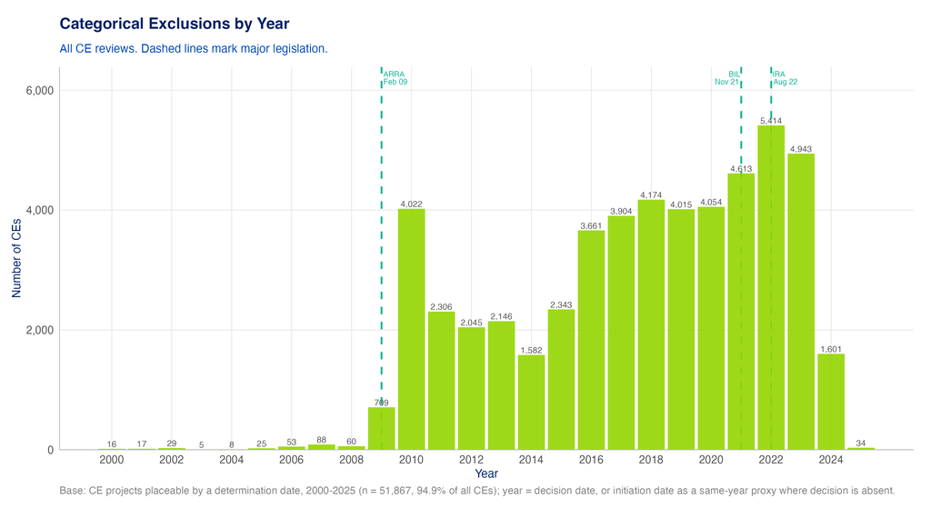

Figure 1: Categorical exclusions by determination year. Dashed lines mark ARRA (2009), BIL (2021), and IRA (2022).

The spike is specific to categorical exclusions. Faceting the same series by review type shows that the more demanding Environmental Assessment and Environmental Impact Statement processes do not exhibit the post-ARRA jump — consistent with a surge of fast, low-burden actions rather than a general increase in NEPA activity.

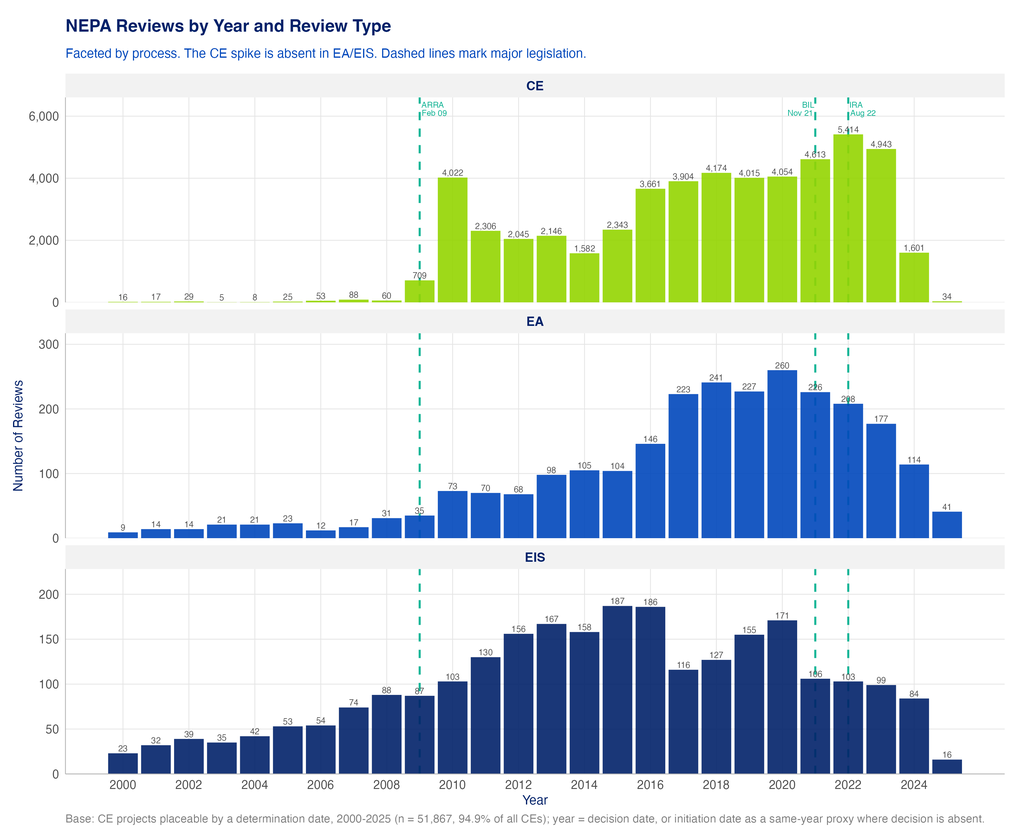

Figure 2: Reviews by year and review type (CE / EA / EIS). The post-ARRA spike appears only in the CE panel.

## The spike is a DOE phenomenon

The post-ARRA CE surge belongs almost entirely to the Department of Energy, the agency that administered ARRA’s energy grants, loan guarantees, and weatherization funds. DOE CEs went from 7 (2008) to 669 (2009) to a peak of 3,942 in 2010. Over the same years the Bureau of Land Management, the only other agency that issues CEs at scale and one drawing on the same dataset, barely moved (40, 76, 104 in 2009–2011). BLM’s own growth comes later (2016 onward) and is unrelated to the legislation. Because both agencies are subject to the identical coverage ramp, this contrast is the cleanest available evidence that the spike is a policy effect, not a data artifact.

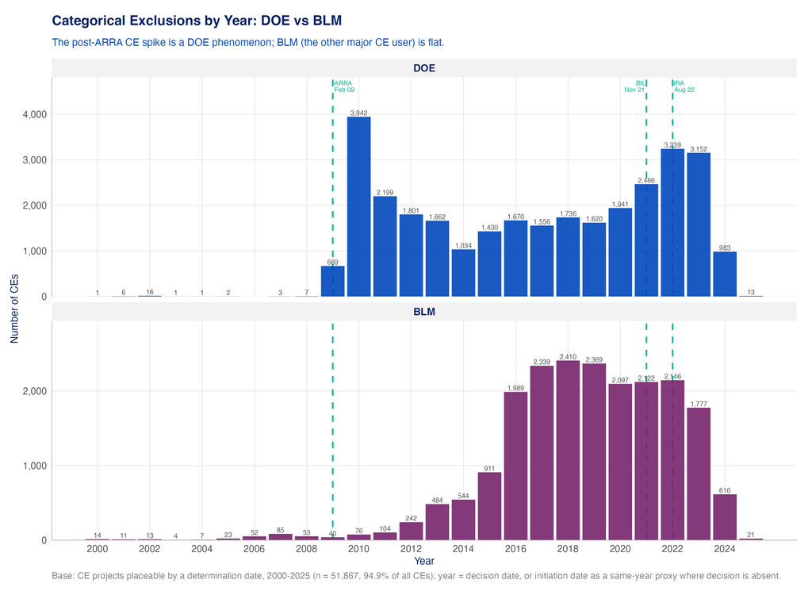

Figure 3: Categorical exclusions by year, DOE vs BLM. The ARRA spike is a DOE phenomenon; BLM is flat through the ARRA window.

Mean monthly CE volume: spike window vs pre-law baseline

| Subset | Law | Window (CEs/mo) | Baseline (CEs/mo) | Spike ratio |
| --- | --- | --- | --- | --- |
| All CE | ARRA | 206.3 | — | — |
| All CE | BIL | 427.8 | 348.3 | 1.23 |
| All CE | IRA | 330.4 | 379.5 | 0.87 |
| DOE | ARRA | 206.0 | — | — |
| DOE | BIL | 263.0 | 164.4 | 1.60 |
| DOE | IRA | 209.9 | 196.1 | 1.07 |
| BLM | ARRA | 6.4 | — | — |
| BLM | BIL | 163.1 | 181.9 | 0.90 |
| BLM | IRA | 119.5 | 181.6 | 0.66 |

ARRA has no usable pre-law baseline (the dataset is sparse before 2009); its spike is established by the DOE-vs-BLM contrast and citation evidence rather than a window/baseline ratio.

## By energy type and department

Splitting the CE series by energy type (decarbonization, fossil, other) and by lead department provides the all-data and breakdown views requested for every analysis.

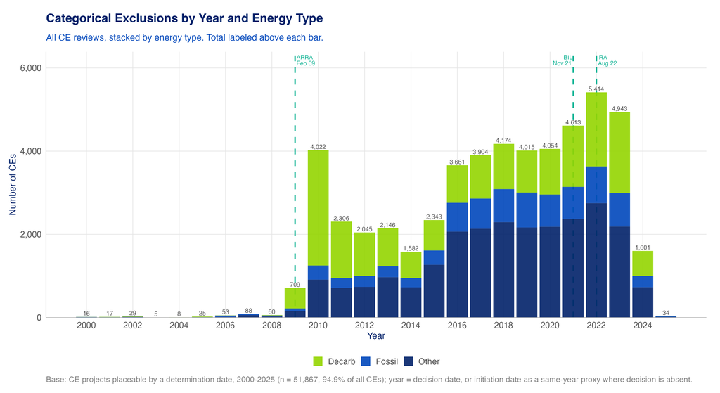

Figure 4: CE counts by year, by energy type.

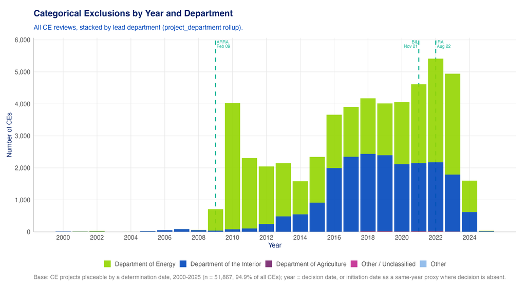

Figure 5: CE counts by year, by lead department.

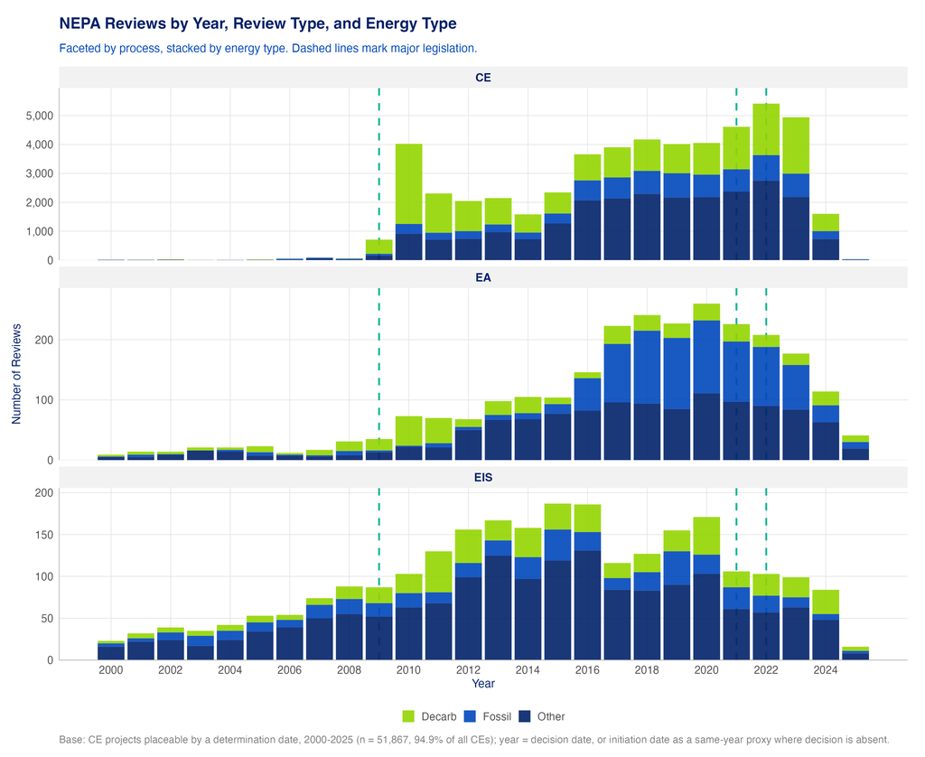

Figure 6: Reviews by year, faceted by review type and stacked by energy type.

# Association With the Law

A temporal coincidence is not attribution. The strongest test is whether the spiking documents state that the action stems from the law. We detect explicit citations to each statute in the document text (with context disambiguation for the ambiguous “IRA” and “BIL” acronyms).

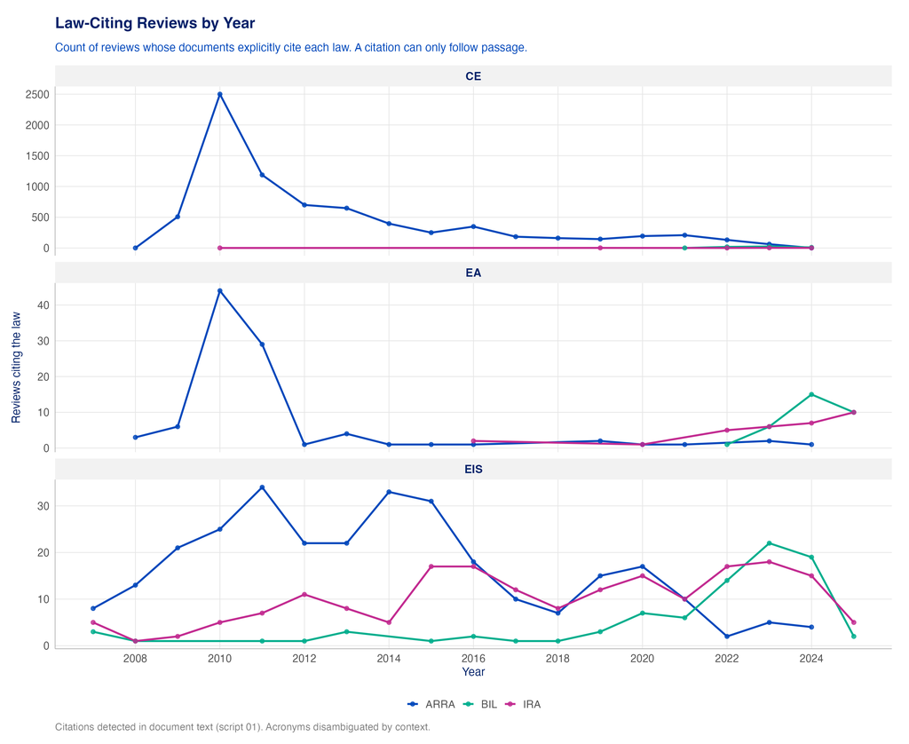

Figure 7: Reviews whose documents explicitly cite each law, by year. A citation cannot precede the law’s passage.

For ARRA the attribution is direct: 59.7% of CEs issued in the ARRA window cite the Recovery Act by name, versus a negligible rate outside it. The Recovery Act citations themselves peak in 2010 and decay over the following years as stimulus obligations wound down — the citation curve tracks the disbursement curve.

BIL and IRA follow a more muted pattern. Their citation rates rise after passage relative to baseline, confirming a real association, but the absolute rate within CEs stays low — these laws are seldom named in a one-page categorical exclusion. They surface far more often in larger reviews: IRA is cited in 18.8% of post-IRA EISs (vs 9.1% before), and BIL in 17.2% of post-BIL EISs. In other words, the citation evidence for BIL/IRA lives in the EIS record, even though the volume signal (more DOE CEs) is real.

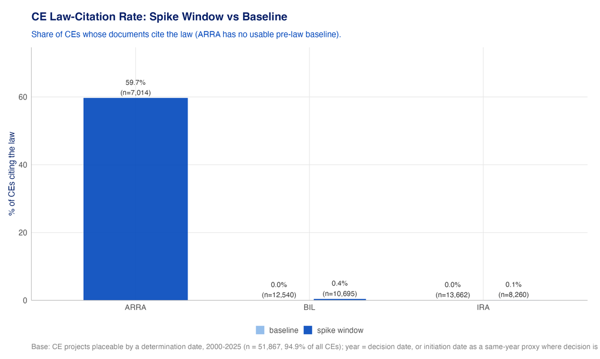

Figure 8: Share of CEs citing each law, spike window vs baseline.

Law-citation rate by scope and period

| Law | Scope | Period | % citing | N |
| --- | --- | --- | --- | --- |
| ARRA | All CE | spike window | 59.7% | 7,014 |
| BIL | All CE | spike window | 0.4% | 10,695 |
| BIL | All CE | baseline | 0.0% | 12,540 |
| IRA | All CE | spike window | 0.1% | 8,260 |
| IRA | All CE | baseline | 0.0% | 13,662 |
| ARRA | All EIS | spike window | 24.8% | 302 |
| BIL | All EIS | spike window | 17.2% | 209 |
| BIL | All EIS | baseline | 3.7% | 433 |
| IRA | All EIS | spike window | 18.8% | 224 |
| IRA | All EIS | baseline | 9.1% | 394 |

# What Types of CEs Were Used

NEPATEC records the specific categorical-exclusion category each action invoked. For DOE these are the codes of 10 C.F.R. 1021 (e.g. `B5.1`, `A9`, `B1.3`); for the Interior/BLM they are the `516 DM 11` series; oil-and-gas drilling uses the Energy Policy Act of 2005 Section 390 exclusion. Comparing the mix inside the ARRA window against a stable baseline shows the categorical-exclusion profile shifting directly toward the stimulus’s purpose.

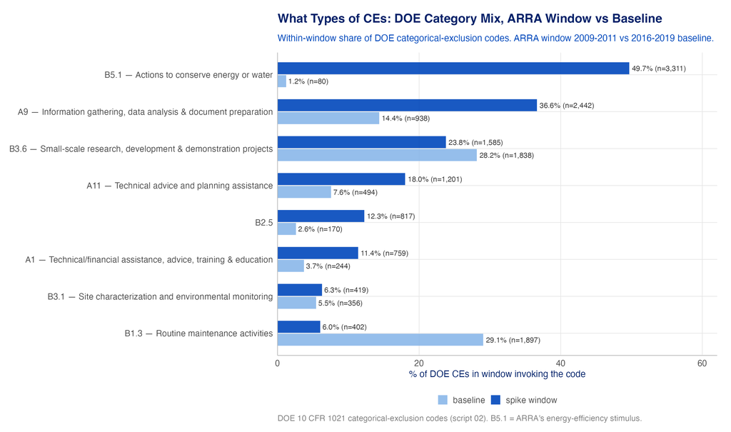

Figure 9: DOE categorical-exclusion category mix, ARRA window (2009-2011) vs 2016-2019 baseline.

The largest shift is in B5.1, “Actions to conserve energy or water,” which accounts for 49.7% of DOE categorical exclusions in the ARRA window versus only 1.2% at baseline, a roughly forty-fold concentration. Information-gathering and technical-assistance categories (A9, A11, A1) are also elevated, consistent with a wave of grant- and study-related actions. By contrast, the baseline period is dominated by routine-maintenance exclusions (B1.3), which recede during the stimulus. The categorical-exclusion mix, in short, reorganizes around energy efficiency exactly when ARRA’s efficiency money arrives.

Top DOE categorical-exclusion codes in the ARRA window

| Code | Description | ARRA window % | Baseline % |
| --- | --- | --- | --- |
| B5.1 | Actions to conserve energy or water | 49.7% | 1.2% |
| A9 | Information gathering, data analysis & document preparation | 36.6% | 14.4% |
| B3.6 | Small-scale research, development & demonstration projects | 23.8% | 28.2% |
| A11 | Technical advice and planning assistance | 18.0% | 7.6% |
| B2.5 | — | 12.3% | 2.6% |
| A1 | Technical/financial assistance, advice, training & education | 11.4% | 3.7% |
| B3.1 | Site characterization and environmental monitoring | 6.3% | 5.5% |
| B1.3 | Routine maintenance activities | 6.0% | 29.1% |

## Technology mix

By project technology, the ARRA-window CEs are dominated by DOE environmental-management and research-and-development categories alongside the expected clean-energy build-out (solar, transmission).

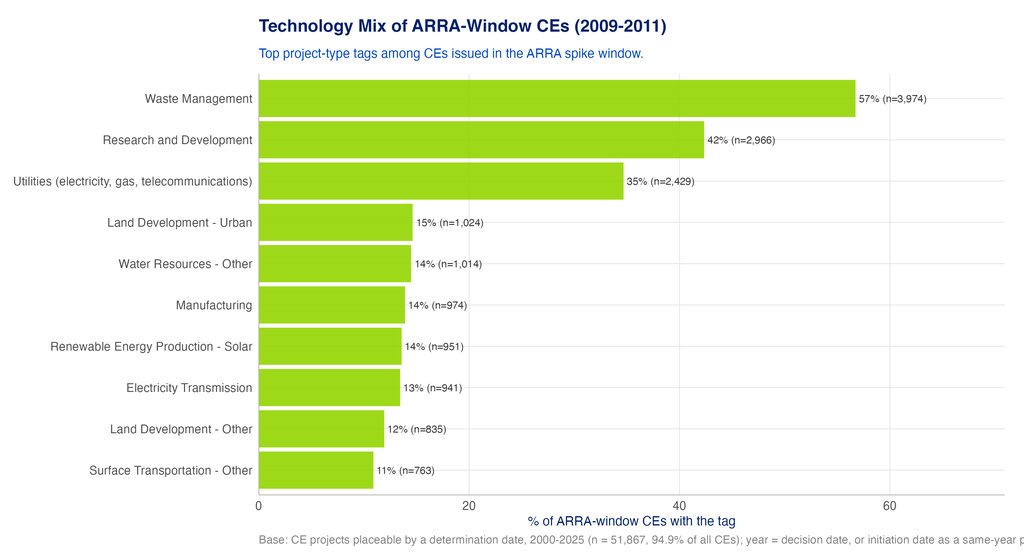

Figure 10: Technology-tag mix of ARRA-window CEs (a project may carry multiple tags).

| Technology tag | Share of ARRA-window CEs | N |
| --- | --- | --- |
| Waste Management | 56.7% | 3,974 |
| Research and Development | 42.3% | 2,966 |
| Utilities (electricity, gas, telecommunications) | 34.7% | 2,429 |
| Land Development - Urban | 14.6% | 1,024 |
| Water Resources - Other | 14.5% | 1,014 |
| Manufacturing | 13.9% | 974 |
| Renewable Energy Production - Solar | 13.6% | 951 |
| Electricity Transmission | 13.4% | 941 |

# Reproducibility

All figures and tables in this report regenerate from committed code. Run from the repository root in the `nepa` conda environment:

```bash
python phase2/code/deliverable05/02_build_ce_categories.py
python phase2/code/deliverable05/01_extract_law_citations.py --source all
Rscript phase2/code/deliverable05/03_create_figures.R
```

Outputs are written to `phase2/output/deliverable05/{figures,diagnostics}/`; the intermediate citation and category datasets to `phase2/data/analysis/deliverable05/`.